# Données sur les accidents de moto

# Etude sur les cycliste

## Age et Sexe des cyclistes

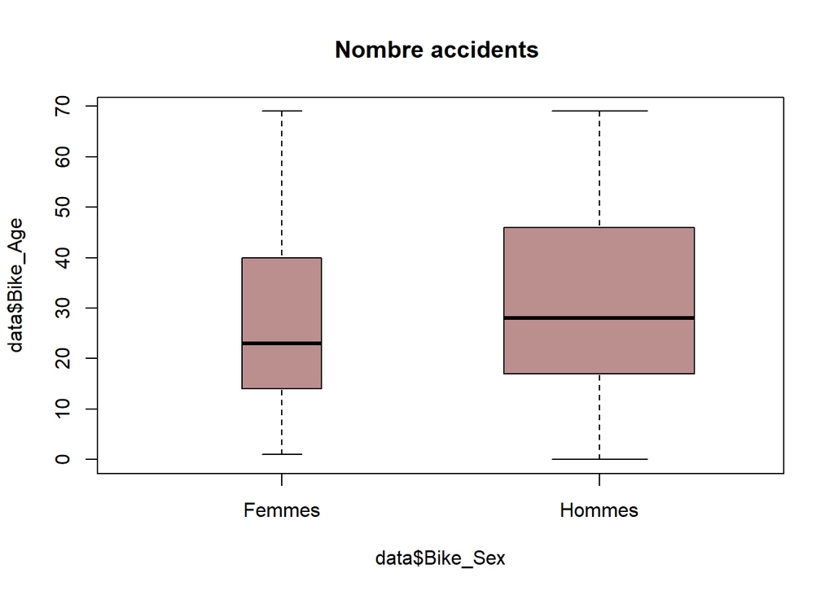

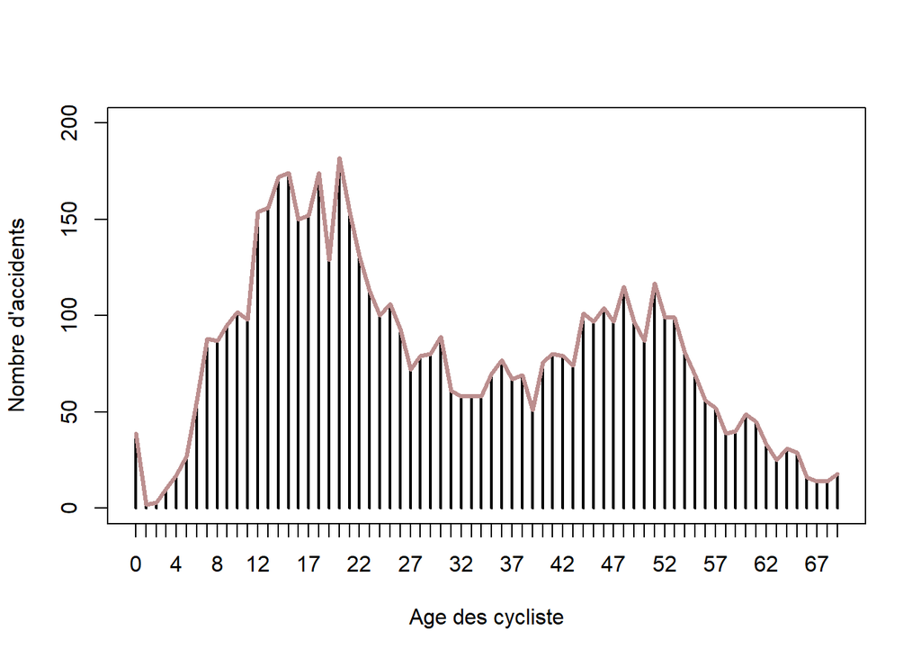

L’age des accidentés varie fortement, cependant on peut constater sur ce graphique que le nombre d’accidents est beaucoup plus élevé pour les individu ayant entre 13 et 21 ans ; Puis s’en suis une forte baise du nombre d’accidents chez les 22-40 ans puis, après une legère augmentation chez les 41-53 ans, le nombre d’accident se réduit considérablement.

## Alcoolémie

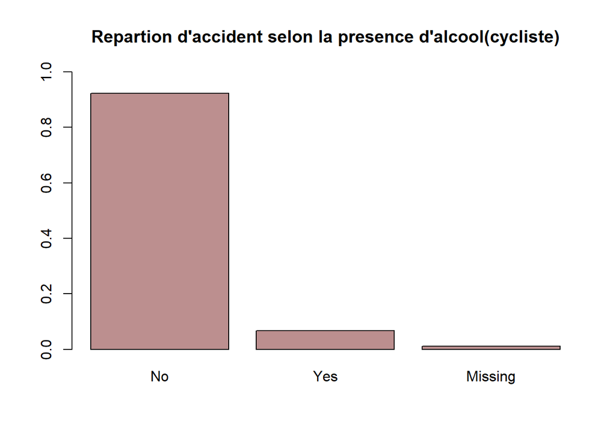

La plupart des accidents ne sont pas dût à l’alccol.

## Race du cycliste

|  | nombre | Proportion |
| --- | --- | --- |
| White | 3111 | 0.5442617 |
| Other | 48 | 0.0083975 |
| native American | 67 | 0.0117215 |
| Hispanic | 297 | 0.0519594 |
| Black | 2006 | 0.3509447 |
| Asian | 56 | 0.0097971 |
| Missing | 131 | 0.0229181 |

[figure not shown]

## Bléssures du cycliste.

| Bike_Injur | Freq |
| --- | --- |
| B: Evident Injury | 2405 |
| C: Possible Injury | 2199 |
| O: No Injury | 526 |
| A: Disabling Injury | 291 |
| Injury | 172 |
| K: Killed | 123 |

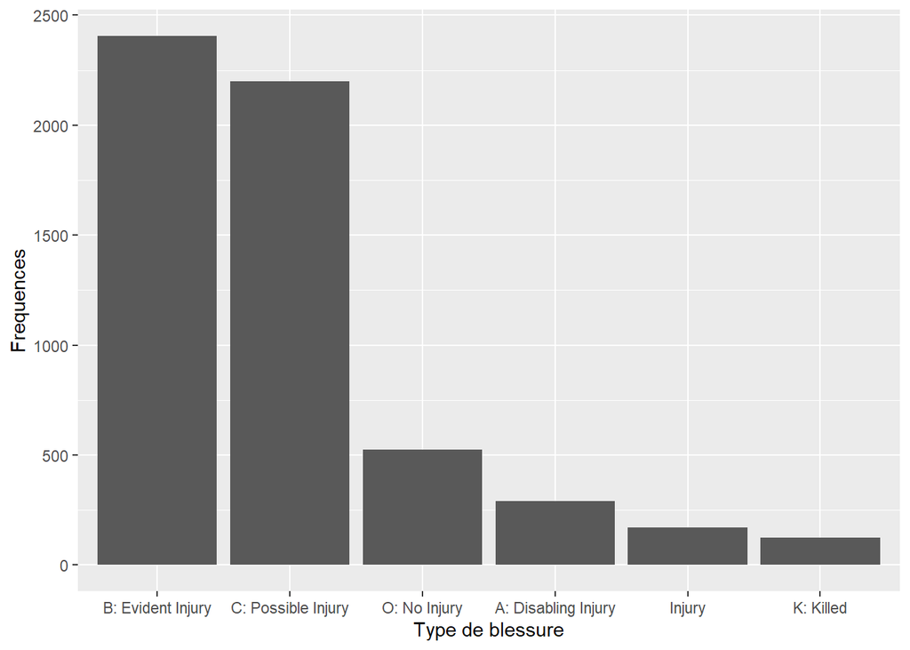

La majeure partie des accidents, bien que n’étant pas mortel, entraine dans la plupart des cas des blessures graves. Ceci s’explique notament parce que la plupart des colision se font avec des automiblistes et que les cyclistes n’ont aucune protections d’aucune sorte.

## Relation entre type de blessure et Position du vélo

| Var1 | Freq |
| --- | --- |
| Travel Lane | 3746 |
| Sidewalk / Crosswalk / Driveway Crossing | 899 |
| Non-Roadway | 309 |
| Bike Lane / Paved Shoulder | 295 |
| Driveway / Alley | 146 |
| Multi-use Path | 36 |
| Other | 32 |

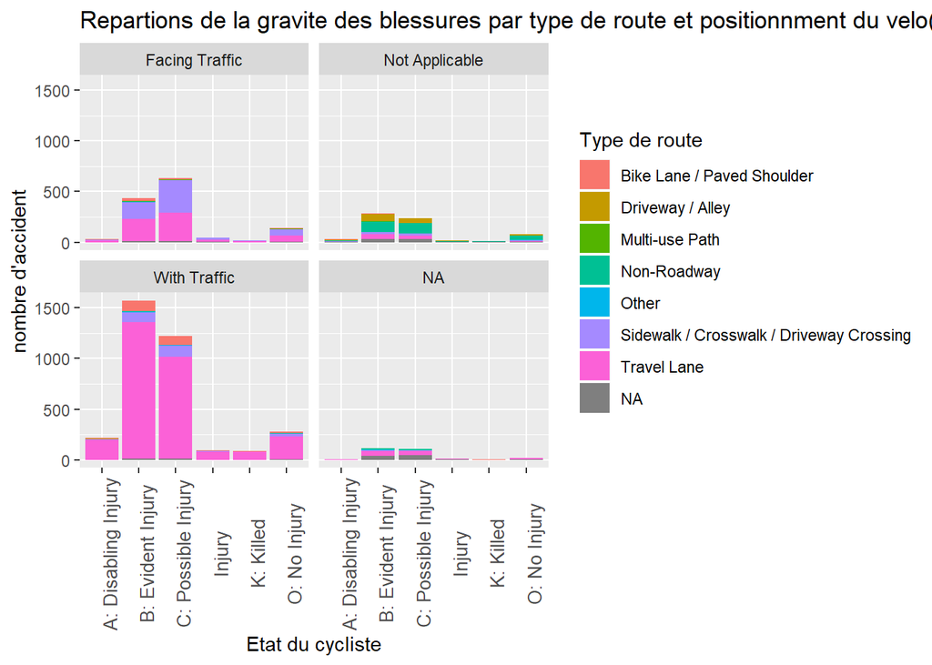

# Etude sur les conducteurs

## Sexe du conducteur

| Var1 | Freq |
| --- | --- |
| Female | 2231 |
| Male | 2727 |

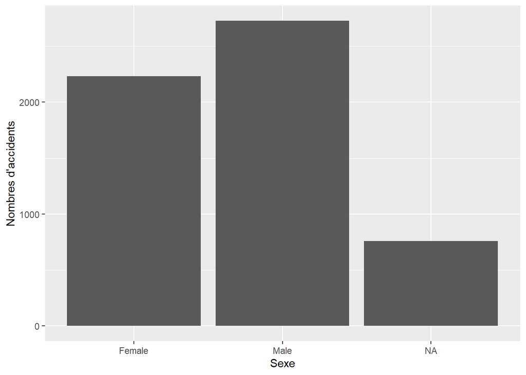

Contrairement aux accidentés qui sont essentiellement des hommes, le sexe des auteurs des accidents est quand à lui repartit plus quitablement entre les hommes et les femmes. Cependant le doute subsiste etant donné le nombre de données manquantes.

## Age des chauffeurs.

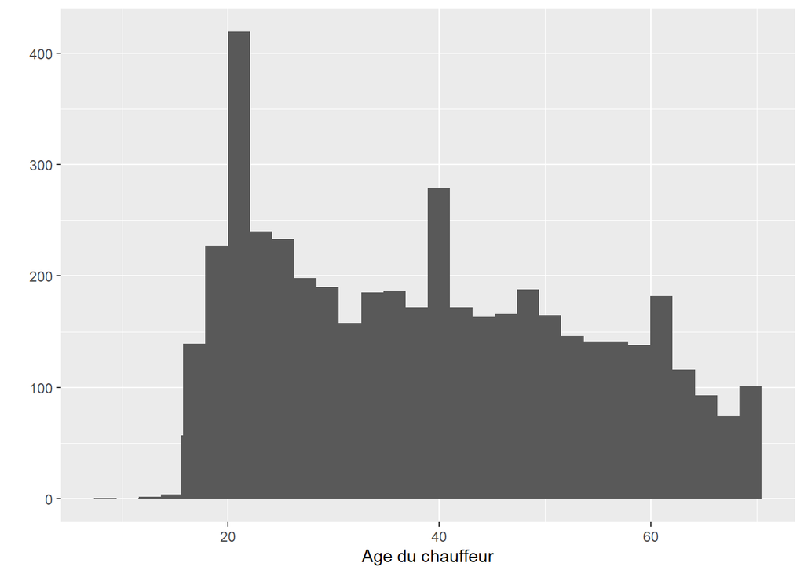

L’age du chauffeur est la variable ayant le plus de données manquantes. Cette representation graphique permet néanmoins d’observer la distribution de l’age des chauffeurs. Trois pics sont a notés, le premier a 21 ans , le second à 40 et enfin le dernier a 60 ans.

## Bléssures des chauffeurs

| Var1 | Freq |
| --- | --- |
| O: No Injury | 0.8341498 |
| Injury | 0.1410077 |
| C: Possible Injury | 0.0143457 |
| B: Evident Injury | 0.0094472 |
| A: Disabling Injury | 0.0006998 |
| K: Killed | 0.0003499 |

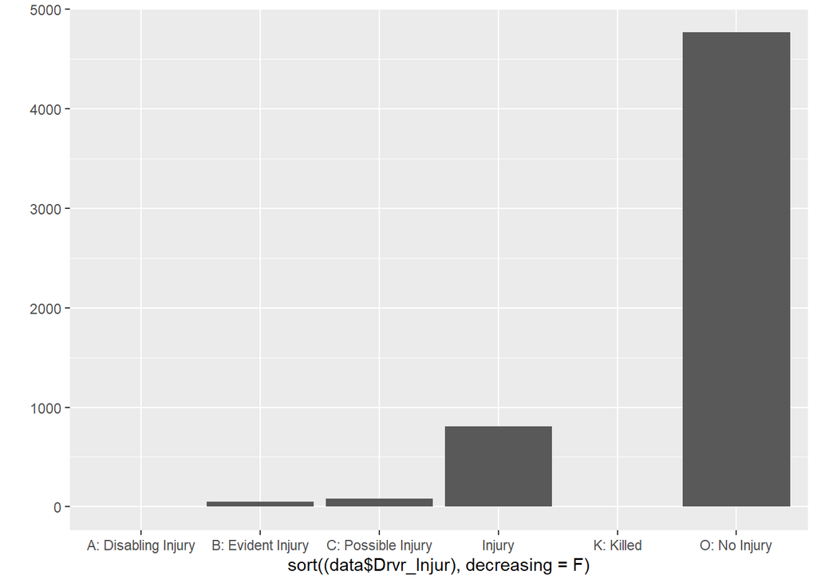

On aurait pu supposer d’intinct qu’un accident entre une voiture et un cycliste ne causeraI que très peu de dommage au conducteur de la voiture, les données le confirme. Dans la plupart des accidents le chauffeur s’en est sorti sans blessures. Il n’y a que 2 morts parmi les 5716 accidents recensés.

## Relation entre la vitesse du chaufeur, sa couleur de peau et le nombre d’accidents

|  | /Missing | Asian | Black | Hispanic | Native American | Other | White |
| --- | --- | --- | --- | --- | --- | --- | --- |
| >100 mph | 0 | 0 | 0 | 0 | 0 | 0 | 2 |
| 0-5 mph | 114 | 14 | 317 | 39 | 5 | 14 | 819 |
| 11-15 mph | 42 | 5 | 123 | 15 | 2 | 7 | 213 |
| 16-20 mph | 48 | 5 | 123 | 9 | 2 | 5 | 222 |
| 21-25 mph | 43 | 4 | 142 | 8 | 4 | 6 | 214 |
| 26-30 mph | 22 | 1 | 91 | 15 | 5 | 2 | 150 |
| 31-35 mph | 92 | 3 | 201 | 20 | 6 | 6 | 324 |
| 36-40 mph | 21 | 3 | 44 | 10 | 2 | 2 | 113 |
| 41-45 mph | 74 | 1 | 99 | 7 | 7 | 3 | 309 |
| 46-50 mph | 8 | 1 | 23 | 3 | 0 | 2 | 70 |
| 51-55 mph | 42 | 1 | 50 | 6 | 20 | 1 | 158 |
| 56-60 mph | 0 | 0 | 4 | 5 | 0 | 0 | 13 |
| 6-10 mph | 74 | 11 | 175 | 20 | 1 | 6 | 340 |
| 61-65 mph | 1 | 1 | 1 | 0 | 0 | 0 | 2 |
| 66-70 mph | 0 | 0 | 1 | 0 | 0 | 0 | 1 |
| 81-85 mph | 0 | 0 | 0 | 0 | 0 | 0 | 1 |

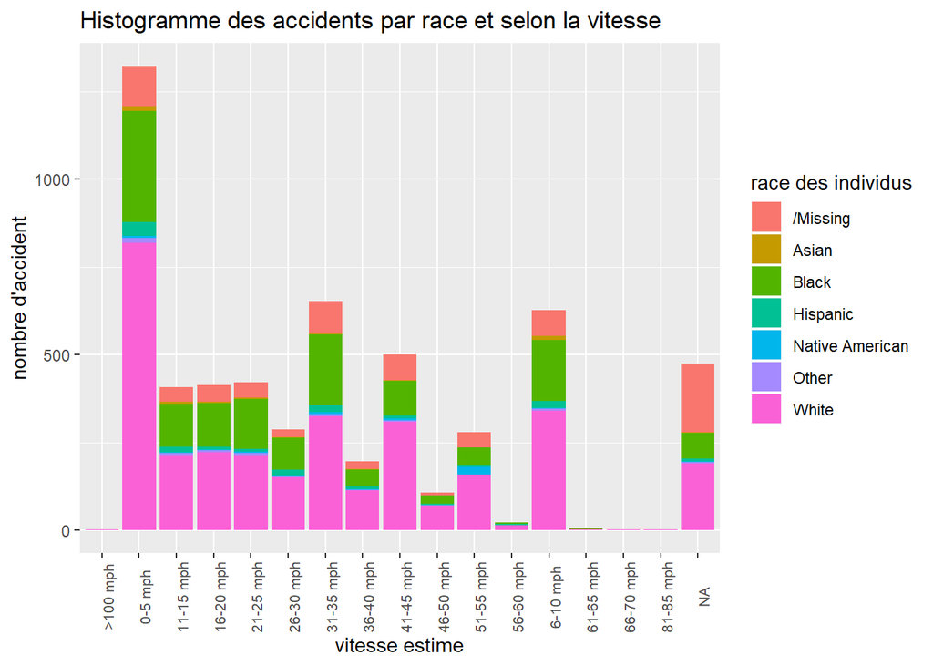

##Alcoolémie

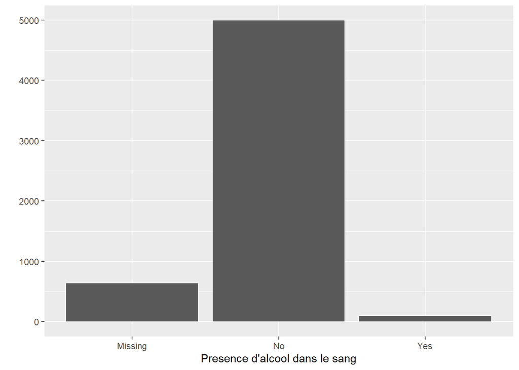

| Var1 | Freq |
| --- | --- |
| Missing | 632 |
| No | 4990 |
| Yes | 94 |

La plupart des chauffeurs n’etaient pas alcoolisés.

## Type de voitures

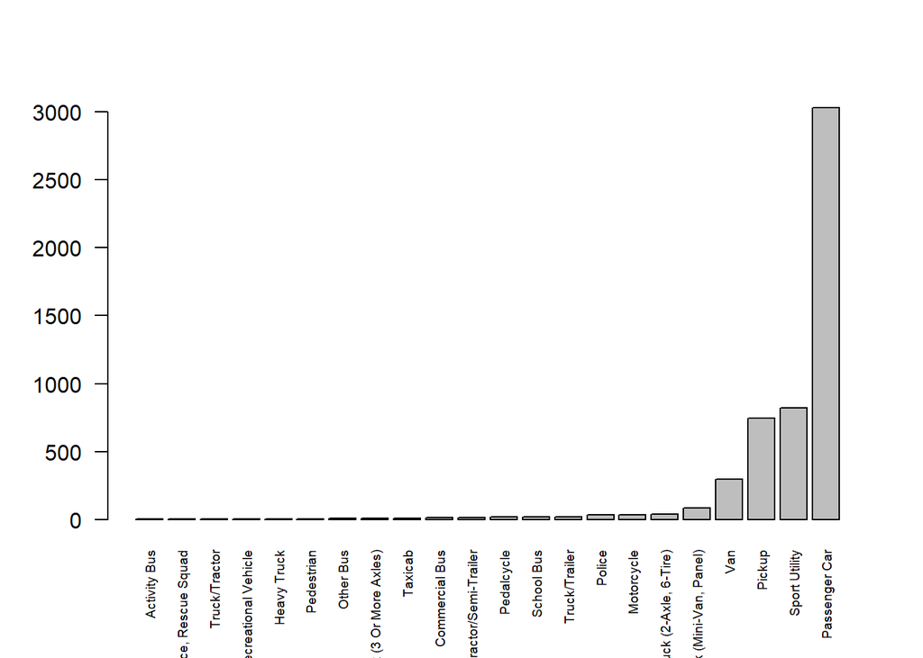

| Var1 | Freq |
| --- | --- |
| Passenger Car | 3032 |
| Sport Utility | 823 |
| Pickup | 745 |
| Van | 294 |
| Light Truck (Mini-Van, Panel) | 85 |
| Single Unit Truck (2-Axle, 6-Tire) | 40 |
| Motorcycle | 36 |
| Police | 35 |
| Pedalcycle | 17 |
| School Bus | 17 |
| Truck/Trailer | 17 |
| Commercial Bus | 14 |
| Tractor/Semi-Trailer | 14 |
| Taxicab | 10 |
| Single Unit Truck (3 Or More Axles) | 9 |
| Other Bus | 8 |
| Heavy Truck | 5 |
| Pedestrian | 5 |
| Motor Home/Recreational Vehicle | 2 |
| Activity Bus | 1 |
| EMS Vehicle, Ambulance, Rescue Squad | 1 |
| Truck/Tractor | 1 |

Les principales types voitures impliqués dans des accidents de vélos sont des voitures familiales, voitures des port, Pickup et Van. Ceci pourrait s’expliquer par le fait que les cycliste se promenant surtout en agglomération ils rencontre surtout ce genre de voiture.

# Etude sur les données temporelles

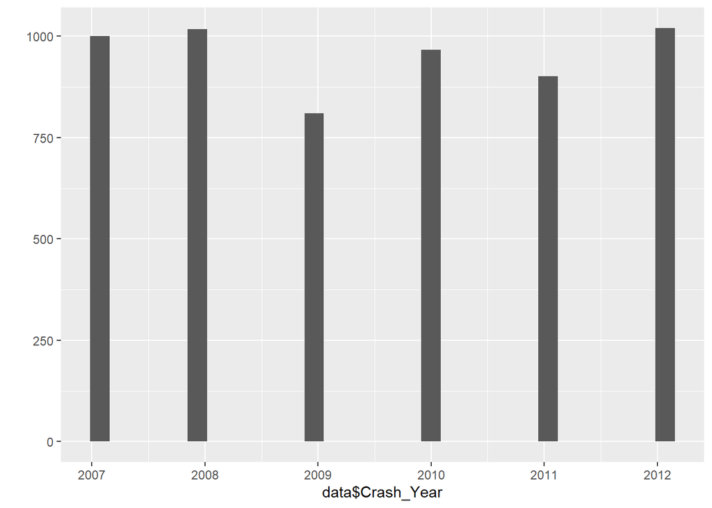

Le premier grahique nous montre que globalement au fil des années le nombre d’accident impliquant un cycliste et un conducteur est resté plus ou moins le même au alentours de 1000 accident sauf au cours de l’année 2009 où nous avons eu une nette diminution d’environ 200 accidents.

Nous avons des maintenant des informations concernant l’heure, le mois(extraite des la variable date) et l’année des differents accidents.

## Evolution du Nombre d’accident par mois en fonction des années

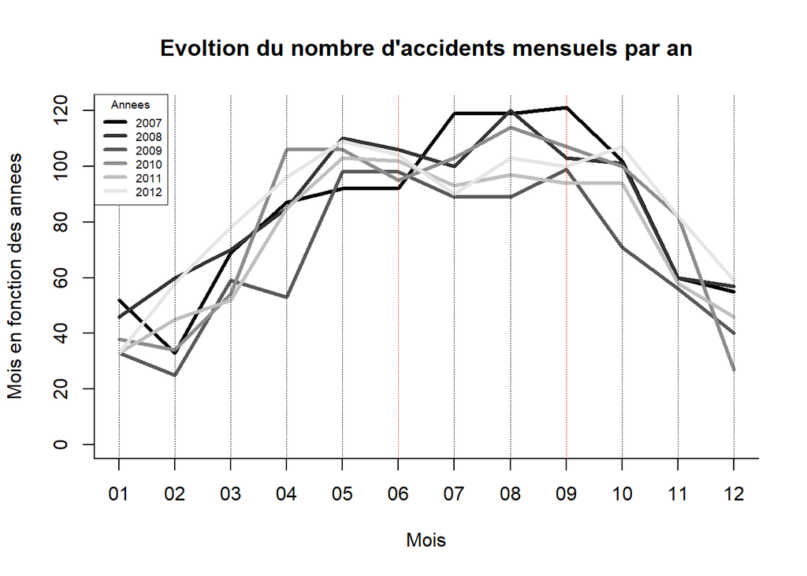

# Carte

## Zoom

Faisons un zoom sur les 4 comtés où le nombre d’accident est le plus important. Elles se trouve dans la meme zone géographique, l’est du Pays.

[figure not shown]

[output not shown]